# IMT 575 Group project

```python
## Load the libraries
import os
import numpy as np
import pandas as pd

# data viz
import matplotlib.pyplot as plt
import seaborn as sns

# machine learning
from sklearn import tree
from sklearn.tree import DecisionTreeClassifier
from sklearn.neighbors import KNeighborsClassifier
from sklearn.ensemble import RandomForestClassifier
from sklearn.model_selection import train_test_split, GridSearchCV
from sklearn.preprocessing import StandardScaler
from sklearn.metrics import accuracy_score, confusion_matrix, classification_report
import xgboost as xgb
import multiprocessing

import warnings
warnings.filterwarnings("ignore")

%matplotlib inline
```

```python
## Load the dataset into a pandas data frame
airbnb_train = pd.read_csv(os.path.abspath('train_users_2.csv'))
airbnb_test = pd.read_csv(os.path.abspath('test_users.csv'))
airbnb_sessions = pd.read_csv(os.path.abspath('sessions.csv'))
```

#### Exploratory analysis

```python
print("There are", airbnb_train.shape[0], "users and",  airbnb_train.shape[1], "features in the training set and", airbnb_test.shape[0], "users and", airbnb_test.shape[1], "features in the test set.")
```

```
There are 213451 users and 16 features in the training set and 62096 users and 15 features in the test set.
```

```python
print("Total users in training and test sets are:", airbnb_train.shape[0]+airbnb_test.shape[0])
```

```
Total users in training and test sets are: 275547
```

```python
print("There are", airbnb_sessions.shape[0], "users and", airbnb_sessions.shape[1], "features in the session set")
```

```
There are 10567737 users and 6 features in the session set
```

Grouping the session data based upon the action, action_type, and action_detail to get the number of actions per user and to group them according to ensure trainability

```python
session1 = airbnb_sessions.groupby(["user_id","action"]).agg({"action": "count"})
session2 = airbnb_sessions.groupby(["user_id","action_type"]).agg({"action_type": "count"})
session3 = airbnb_sessions.groupby(["user_id","action_detail"]).agg({"action_detail": "count"})

session1 = session1.rename(columns={'action':'action_count'}).reset_index()
session2 = session2.rename(columns={'action_type':'action_type_count'}).reset_index()
session3 = session3.rename(columns={'action_detail':'action_detail_count'}).reset_index()
```

Now we need to pivot the data in the broken down session data to make the data wider and more readable by the machine learning models

```python
session1 = session1.pivot_table(index='user_id', columns='action', values='action_count').fillna(0)
session2 = session2.pivot_table(index='user_id', columns='action_type', values='action_type_count').fillna(0)
session3 = session3.pivot_table(index='user_id', columns='action_detail', values='action_detail_count').fillna(0)

session_pivot = session1.merge(session2, on='user_id', how='outer').merge(session3, on='user_id', how='outer')
```

```python
session_pivot.head()
```

| user_id | 10 | 11 | 12 | 15 | about_us | accept_decline | account | acculynk_bin_check_failed | acculynk_bin_check_success | acculynk_load_pin_pad | ... | view_resolutions | view_search_results | view_security_checks | view_user_real_names | wishlist | wishlist_content_update | wishlist_note | your_listings | your_reservations | your_trips |
| --- | --- | --- | --- | --- | --- | --- | --- | --- | --- | --- | --- | --- | --- | --- | --- | --- | --- | --- | --- | --- | --- |
| 00023iyk9l | 0.0 | 0.0 | 0.0 | 0.0 | 0.0 | 0.0 | 0.0 | 0.0 | 0.0 | 0.0 | ... | 0.0 | 5.0 | 0.0 | 0.0 | 0.0 | 4.0 | 0.0 | 0.0 | 0.0 | 2.0 |
| 0010k6l0om | 0.0 | 0.0 | 0.0 | 0.0 | 0.0 | 0.0 | 0.0 | 0.0 | 0.0 | 0.0 | ... | 0.0 | 10.0 | 0.0 | 0.0 | 0.0 | 8.0 | 0.0 | 0.0 | 0.0 | 0.0 |
| 001wyh0pz8 | 0.0 | 0.0 | 0.0 | 0.0 | 0.0 | 0.0 | 0.0 | 0.0 | 0.0 | 0.0 | ... | 0.0 | 66.0 | 0.0 | 0.0 | 0.0 | 0.0 | 0.0 | 0.0 | 0.0 | 0.0 |
| 0028jgx1x1 | 0.0 | 0.0 | 0.0 | 0.0 | 0.0 | 0.0 | 0.0 | 0.0 | 0.0 | 0.0 | ... | 0.0 | 9.0 | 0.0 | 0.0 | 0.0 | 0.0 | 0.0 | 0.0 | 0.0 | 0.0 |
| 002qnbzfs5 | 9.0 | 0.0 | 0.0 | 0.0 | 0.0 | 0.0 | 0.0 | 0.0 | 0.0 | 0.0 | ... | 0.0 | 125.0 | 0.0 | 0.0 | 0.0 | 0.0 | 0.0 | 0.0 | 0.0 | 0.0 |

5 rows × 524 columns

##### Now joining both train and session datasets together

```python
airbnb_df = airbnb_train.merge(session_pivot, left_on='id', right_on='user_id', how='inner')
```

```python
print("There are", airbnb_df.shape[0],"observations and", airbnb_df.shape[1], "features in the dataset")
```

```
There are 73815 observations and 540 features in the dataset
```

```python
airbnb_df.head()
```

|  | id | date_account_created | timestamp_first_active | date_first_booking | gender | age | signup_method | signup_flow | language | affiliate_channel | ... | view_resolutions | view_search_results | view_security_checks | view_user_real_names | wishlist | wishlist_content_update | wishlist_note | your_listings | your_reservations | your_trips |
| --- | --- | --- | --- | --- | --- | --- | --- | --- | --- | --- | --- | --- | --- | --- | --- | --- | --- | --- | --- | --- | --- |
| 0 | d1mm9tcy42 | 2014-01-01 | 20140101000936 | 2014-01-04 | MALE | 62.0 | basic | 0 | en | sem-non-brand | ... | 0.0 | 23.0 | 0.0 | 0.0 | 0.0 | 25.0 | 0.0 | 0.0 | 0.0 | 0.0 |
| 1 | yo8nz8bqcq | 2014-01-01 | 20140101001558 | NaN | -unknown- | NaN | basic | 0 | en | direct | ... | 0.0 | 0.0 | 0.0 | 0.0 | 0.0 | 1.0 | 0.0 | 0.0 | 0.0 | 0.0 |
| 2 | 4grx6yxeby | 2014-01-01 | 20140101001639 | NaN | -unknown- | NaN | basic | 0 | en | sem-brand | ... | 0.0 | 0.0 | 0.0 | 0.0 | 0.0 | 1.0 | 0.0 | 0.0 | 0.0 | 0.0 |
| 3 | ncf87guaf0 | 2014-01-01 | 20140101002146 | NaN | -unknown- | NaN | basic | 0 | en | direct | ... | 0.0 | 32.0 | 0.0 | 0.0 | 0.0 | 10.0 | 0.0 | 0.0 | 0.0 | 0.0 |
| 4 | 4rvqpxoh3h | 2014-01-01 | 20140101002619 | 2014-01-02 | -unknown- | NaN | basic | 25 | en | direct | ... | 0.0 | 0.0 | 0.0 | 0.0 | 0.0 | 0.0 | 0.0 | 0.0 | 0.0 | 0.0 |

5 rows × 540 columns

By looking at the data, we can see that `gender` and `first browser` columns have `unknown` values. Replacing `unknown` with `NaN`.

```python
airbnb_df.replace('-unknown-', np.nan, inplace=True)
```

```python
airbnb_df.head()
```

|  | id | date_account_created | timestamp_first_active | date_first_booking | gender | age | signup_method | signup_flow | language | affiliate_channel | ... | view_resolutions | view_search_results | view_security_checks | view_user_real_names | wishlist | wishlist_content_update | wishlist_note | your_listings | your_reservations | your_trips |
| --- | --- | --- | --- | --- | --- | --- | --- | --- | --- | --- | --- | --- | --- | --- | --- | --- | --- | --- | --- | --- | --- |
| 0 | d1mm9tcy42 | 2014-01-01 | 20140101000936 | 2014-01-04 | MALE | 62.0 | basic | 0 | en | sem-non-brand | ... | 0.0 | 23.0 | 0.0 | 0.0 | 0.0 | 25.0 | 0.0 | 0.0 | 0.0 | 0.0 |
| 1 | yo8nz8bqcq | 2014-01-01 | 20140101001558 | NaN | NaN | NaN | basic | 0 | en | direct | ... | 0.0 | 0.0 | 0.0 | 0.0 | 0.0 | 1.0 | 0.0 | 0.0 | 0.0 | 0.0 |
| 2 | 4grx6yxeby | 2014-01-01 | 20140101001639 | NaN | NaN | NaN | basic | 0 | en | sem-brand | ... | 0.0 | 0.0 | 0.0 | 0.0 | 0.0 | 1.0 | 0.0 | 0.0 | 0.0 | 0.0 |
| 3 | ncf87guaf0 | 2014-01-01 | 20140101002146 | NaN | NaN | NaN | basic | 0 | en | direct | ... | 0.0 | 32.0 | 0.0 | 0.0 | 0.0 | 10.0 | 0.0 | 0.0 | 0.0 | 0.0 |
| 4 | 4rvqpxoh3h | 2014-01-01 | 20140101002619 | 2014-01-02 | NaN | NaN | basic | 25 | en | direct | ... | 0.0 | 0.0 | 0.0 | 0.0 | 0.0 | 0.0 | 0.0 | 0.0 | 0.0 | 0.0 |

5 rows × 540 columns

```python
## Checking for missing value
airbnb_df.isnull().sum()
```

```
id                             0
date_account_created           0
timestamp_first_active         0
date_first_booking         45041
gender                     37788
                           ...
wishlist_content_update        3
wishlist_note                  3
your_listings                  3
your_reservations              3
your_trips                     3
Length: 540, dtype: int64
```

##### Univariant analysis

We will see the distribution of target variable `country_destination`

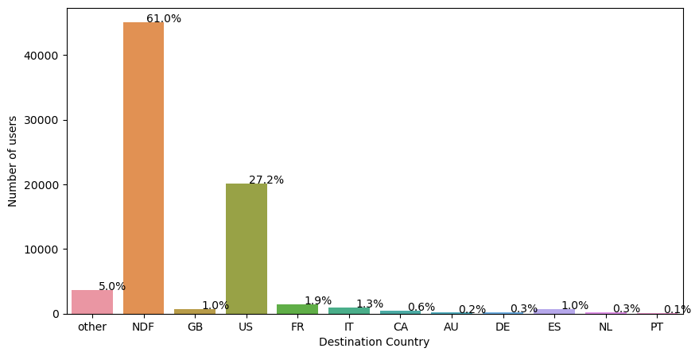

```python
plt.figure(figsize=(10,5))
total = float(len(airbnb_df))
plot = sns.countplot(x='country_destination', data=airbnb_df)
plt.xlabel('Destination Country')
plt.ylabel('Number of users')
for p in plot.patches:
    percentage = '{:.1f}%'.format(100 * p.get_height()/total)
    x = p.get_x() + p.get_width()
    y = p.get_height()
    plot.annotate(percentage, (x, y),ha='center')
```

The data in the above graph shows that 61% of users did not book any destination (NDF-No destination found) and US(27%) seems to be a most booked country. Since all users in the dataset are from US, it shows that US travlers most likely to travel within US. Here we are only considering users who made at least one reservation, therefore we need to exclude NDF from the target column `country_destination`.

```python
airbnb_df = airbnb_df[airbnb_df['country_destination']!='NDF']
```

##### Analyzing the user's age

```python
airbnb_df.age.describe()
```

```
count    22700.000000
mean        41.917753
std        106.748982
min         15.000000
25%         27.000000
50%         32.000000
75%         41.000000
max       2014.000000
Name: age, dtype: float64
```

The maximum age is 2014 which could not be possible. It looks like a year. We need to change the age column from year to age. Also need to set the limit for age like minimum age and maximum age.

```python
airbnb_df_with_year = airbnb_df['age'] > 1000
airbnb_df.loc[airbnb_df_with_year, 'age'] = 2015 - airbnb_df.loc[airbnb_df_with_year, 'age']
airbnb_df.loc[airbnb_df.age > 95, 'age'] = np.nan
airbnb_df.loc[airbnb_df.age < 16, 'age'] = np.nan
airbnb_df['age'].fillna(-1, inplace=True)
```

```python
airbnb_df.head()
```

|  | id | date_account_created | timestamp_first_active | date_first_booking | gender | age | signup_method | signup_flow | language | affiliate_channel | ... | view_resolutions | view_search_results | view_security_checks | view_user_real_names | wishlist | wishlist_content_update | wishlist_note | your_listings | your_reservations | your_trips |
| --- | --- | --- | --- | --- | --- | --- | --- | --- | --- | --- | --- | --- | --- | --- | --- | --- | --- | --- | --- | --- | --- |
| 0 | d1mm9tcy42 | 2014-01-01 | 20140101000936 | 2014-01-04 | MALE | 62.0 | basic | 0 | en | sem-non-brand | ... | 0.0 | 23.0 | 0.0 | 0.0 | 0.0 | 25.0 | 0.0 | 0.0 | 0.0 | 0.0 |
| 4 | 4rvqpxoh3h | 2014-01-01 | 20140101002619 | 2014-01-02 | NaN | -1.0 | basic | 25 | en | direct | ... | 0.0 | 0.0 | 0.0 | 0.0 | 0.0 | 0.0 | 0.0 | 0.0 | 0.0 | 0.0 |
| 6 | xwxei6hdk4 | 2014-01-01 | 20140101002742 | 2014-01-07 | FEMALE | 32.0 | facebook | 0 | en | seo | ... | 0.0 | 0.0 | 0.0 | 0.0 | 0.0 | 0.0 | 0.0 | 0.0 | 0.0 | 0.0 |
| 8 | ro2stddszp | 2014-01-01 | 20140101005503 | 2014-12-04 | NaN | 19.0 | basic | 0 | en | sem-brand | ... | 0.0 | 5.0 | 0.0 | 0.0 | 0.0 | 7.0 | 0.0 | 0.0 | 0.0 | 0.0 |
| 10 | awiurksqr3 | 2014-01-01 | 20140101010113 | 2014-01-02 | FEMALE | 32.0 | facebook | 0 | en | direct | ... | 0.0 | 0.0 | 0.0 | 0.0 | 0.0 | 0.0 | 0.0 | 0.0 | 0.0 | 0.0 |

5 rows × 540 columns

```python
# Cast date time column to property date time format and Split dates into day, week, month, year.
airbnb_df["date_account_created"] = pd.to_datetime(airbnb_df["date_account_created"])
airbnb_df["date_account_created_day"] = airbnb_df.date_account_created.dt.weekday
airbnb_df["date_account_created_month"] = airbnb_df.date_account_created.dt.month
airbnb_df["date_account_created_year"] = airbnb_df.date_account_created.dt.year

# Cast date time column to property date time format and split dates into day, week, month, year.
airbnb_df['timestamp_first_active'] = pd.to_datetime(airbnb_df['timestamp_first_active'], format='%Y%m%d%H%M%S')
airbnb_df["timestamp_first_active_day"] = airbnb_df.timestamp_first_active.dt.weekday
airbnb_df["timestamp_first_active_month"] = airbnb_df.timestamp_first_active.dt.month
airbnb_df["timestamp_first_active_year"] = airbnb_df.timestamp_first_active.dt.year
airbnb_df["timestamp_first_active_hour"] = airbnb_df.timestamp_first_active.dt.hour

# Make the split datatime fields into object data types for model training
airbnb_df["date_account_created_day"] = airbnb_df["date_account_created_day"].astype("O")
airbnb_df["date_account_created_month"] = airbnb_df["date_account_created_month"].astype("O")
airbnb_df["date_account_created_year"] = airbnb_df["date_account_created_year"].astype("O")
airbnb_df["timestamp_first_active_day"] = airbnb_df["timestamp_first_active_day"].astype("O")
airbnb_df["timestamp_first_active_month"] = airbnb_df["timestamp_first_active_month"].astype("O")
airbnb_df["timestamp_first_active_year"] = airbnb_df["timestamp_first_active_year"].astype("O")
airbnb_df["timestamp_first_active_hour"] = airbnb_df["timestamp_first_active_hour"].astype("O")

# Change the signup_flow to an object data type
airbnb_df["signup_flow"] = airbnb_df["signup_flow"].astype("O")

# Dropping these columns because they have already been altered and don't need duplicate data types
drop_cols = ["date_account_created","timestamp_first_active","date_first_booking", "age", "id"]
airbnb_df.drop(columns=drop_cols, inplace=True)
```

[figure not shown]

```python
plt.figure(figsize=(10,5))
total = float(len(airbnb_df))
plot = sns.countplot(x='timestamp_first_active_day', data=airbnb_df)
plt.xlabel('Day of Week')
plt.ylabel('Number of users')
plt.xticks([0, 1, 2, 3, 4, 5, 6], ['Sunday', 'Monday', 'Tuesday', 'Wednesday', 'Thursday', 'Friday', 'Saturday'])
for p in plot.patches:
    percentage = '{:.1f}%'.format(100 * p.get_height()/total)
    x = p.get_x() + p.get_width()
    y = p.get_height()
    plot.annotate(percentage, (x, y),ha='center')
```

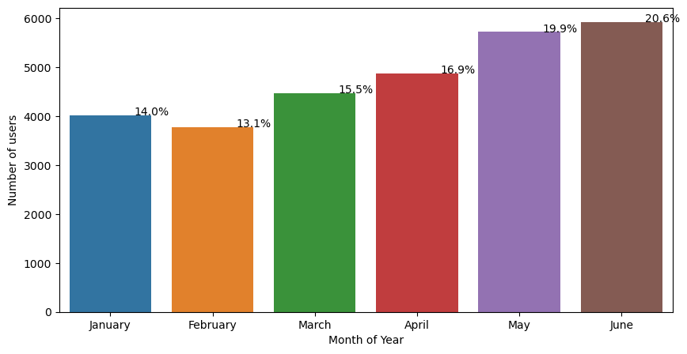

```python
plt.figure(figsize=(10,5))
total = float(len(airbnb_df))
plot = sns.countplot(x='timestamp_first_active_month', data=airbnb_df)
plt.xlabel('Month of Year')
plt.ylabel('Number of users')
plt.xticks([0, 1, 2, 3, 4, 5], ['January', 'February', 'March', 'April', 'May', 'June'])

for p in plot.patches:
    percentage = '{:.1f}%'.format(100 * p.get_height()/total)
    x = p.get_x() + p.get_width()
    y = p.get_height()
    plot.annotate(percentage, (x, y),ha='center')
```

The above plot shows the relationship between the month of year and the number of users that first started using the Airbnb application. There is an upward tick from January to June in this dataset which would lead us to believe that there is a relationship between month of year and number of new users.

```python
# Getting categorical datasets ready for One Hot Encoding
cat_cols = [col for col in airbnb_df.columns if airbnb_df[col].dtype =="O"]
cat_cols.remove("country_destination")

print(cat_cols)

# One Hot Encoding for the category datasets
train_df = pd.get_dummies(airbnb_df, columns=cat_cols, drop_first=True)
train_df.info()
```

```
['gender', 'signup_method', 'signup_flow', 'language', 'affiliate_channel', 'affiliate_provider', 'first_affiliate_tracked', 'signup_app', 'first_device_type', 'first_browser', 'date_account_created_day', 'date_account_created_month', 'date_account_created_year', 'timestamp_first_active_day', 'times…
<class 'pandas.core.frame.DataFrame'>
Int64Index: 28774 entries, 0 to 73809
Columns: 666 entries, country_destination to timestamp_first_active_hour_23
dtypes: float64(524), object(1), uint8(141)
memory usage: 119.3+ MB
```

```python
train_df.reset_index(inplace=True)
train_df.fillna(-1, inplace=True)
```

```python
from sklearn.preprocessing import LabelEncoder

y = train_df['country_destination']
X = train_df.drop(columns='country_destination')

# Get unique values of the column
unique_values = train_df['country_destination'].unique()

# Initialize and fit the LabelEncoder
le = LabelEncoder()
le.fit(unique_values)

# Transform the target variable using labels
y_xgb = le.transform(y)
```

```python
X_train, X_test, y_train, y_test = train_test_split(X, y, test_size =0.25, random_state=12)
```

### Model Training

#### Decision Tree Clasification

```python
tree_model = DecisionTreeClassifier(criterion='gini', max_depth=5, min_samples_split= 50)
tree_model.fit(X_train, y_train)
y_pred = tree_model.predict(X_test)
accuracy = accuracy_score(y_test, y_pred)
print(classification_report(y_test, y_pred))
print('Accuracy of decision tree model is {:.5f}'.format(accuracy))
```

```
              precision    recall  f1-score   support

          AU       0.00      0.00      0.00        42
          CA       0.00      0.00      0.00       115
          DE       0.00      0.00      0.00        64
          ES       0.00      0.00      0.00       180
          FR       0.50      0.01      0.01       378
          GB       0.00      0.00      0.00       206
          IT       0.08      0.00      0.01       228
          NL       0.00      0.00      0.00        53
          PT       0.00      0.00      0.00        21
          US       0.70      1.00      0.82      5016
       other       0.00      0.00      0.00       891

    accuracy                           0.70      7194
   macro avg       0.12      0.09      0.08      7194
weighted avg       0.52      0.70      0.57      7194

Accuracy of decision tree model is 0.69739
```

#### Random Forest Classification

```python
randomforest_model = RandomForestClassifier(n_estimators = 500, criterion='gini', max_depth=6)
randomforest_model.fit(X_train, y_train)
y_pred = randomforest_model.predict(X_test)
accuracy = accuracy_score(y_test, y_pred)
print(classification_report(y_test, y_pred))
print('Accuracy of random forest model is {:.5f}'.format(accuracy))
```

```
              precision    recall  f1-score   support

          AU       0.00      0.00      0.00        42
          CA       0.00      0.00      0.00       115
          DE       0.00      0.00      0.00        64
          ES       0.00      0.00      0.00       180
          FR       0.00      0.00      0.00       378
          GB       0.00      0.00      0.00       206
          IT       0.00      0.00      0.00       228
          NL       0.00      0.00      0.00        53
          PT       0.00      0.00      0.00        21
          US       0.70      1.00      0.82      5016
       other       0.00      0.00      0.00       891

    accuracy                           0.70      7194
   macro avg       0.06      0.09      0.07      7194
weighted avg       0.49      0.70      0.57      7194

Accuracy of random forest model is 0.69725
```

#### XGBoost Classification

```python
X_train, X_test, y_train, y_test = train_test_split(X, y_xgb, test_size =0.25, random_state=12)
```

```python
print("Parallel Parameter optimization")
xgb_model = xgb.XGBClassifier(n_jobs=multiprocessing.cpu_count() // 2)
clf = GridSearchCV(xgb_model, {'max_depth': [2, 4, 6],
                               'n_estimators': [50, 100, 200]}, verbose=1,
                   n_jobs=2)
clf.fit(X_train, y_train)

print(clf.best_score_)
print(clf.best_params_)
```

```
Parallel Parameter optimization
Fitting 5 folds for each of 9 candidates, totalling 45 fits
0.6987951807228916
{'max_depth': 2, 'n_estimators': 100}
```

```python
xgb_model = xgb.XGBClassifier(max_depth=2, n_estimators=100)
xgb_model.fit(X_train, y_train)
y_pred = xgb_model.predict(X_test)
accuracy = accuracy_score(y_test, y_pred)
print(classification_report(y_test, y_pred))
print('Accuracy of XGBoost Model is {:.5f}'.format(accuracy))
```

```
              precision    recall  f1-score   support

           0       0.00      0.00      0.00        42
           1       0.00      0.00      0.00       115
           2       0.00      0.00      0.00        64
           3       0.00      0.00      0.00       180
           4       0.40      0.01      0.02       378
           5       0.00      0.00      0.00       206
           6       0.20      0.00      0.01       228
           7       0.00      0.00      0.00        53
           8       0.00      0.00      0.00        21
           9       0.70      1.00      0.82      5016
          10       0.44      0.01      0.02       891

    accuracy                           0.70      7194
   macro avg       0.16      0.09      0.08      7194
weighted avg       0.57      0.70      0.58      7194

Accuracy of XGBoost Model is 0.69794
```